# La méthode diviser pour régner

Une stratégie efficace

B. DARID

2026

# 1 Introduction : L’union fait la force

Face à un problème complexe (traiter des millions de données bancaires ou classer des archives électorales), la stratégie la plus efficace n’est pas de travailler plus vite, mais de **mieux organiser le travail**.

La méthode «Diviser pour régner» (*Divide and Conquer*) est un paradigme algorithmique qui consiste à décomposer un problème en sous-problèmes plus petits, jusqu’à ce qu’ils deviennent faciles à résoudre.

**Repère historique**

En 1945, dans son texte fondateur [First Draft of a Report on the EDVAC](https://web.mit.edu/sts.035/www/PDFs/edvac.pdf), le mathématicien John von Neumann formalise l’architecture des ordinateurs modernes. Puis, en 1948, décrit [le tri fusion](http://bitsavers.informatik.uni-stuttgart.de/pdf/ias/Planning_and_Coding_of_Problems_for_an_Electronic_Computing_Instrument_Part_II_Volume_II_Apr48.pdf) (Merge Sort). C’est la première application documentée de la stratégie «Diviser pour régner» sur une machine électronique.

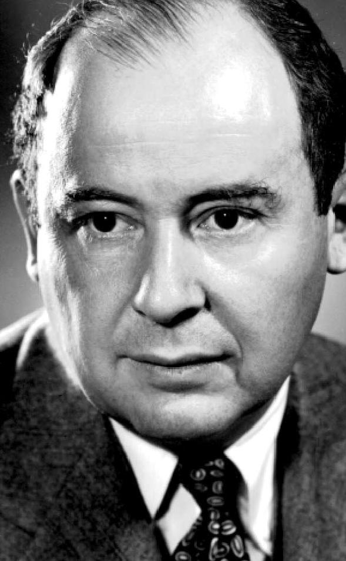

John von Neumann

# 2 Le triptyque de la méthode

[figure not shown]

Diviser pour régner

Pour appliquer cette stratégie, on suit rigoureusement trois étapes:

- **DIVISER**: on découpe le problème initial en plusieurs sous-problèmes identiques mais de taille plus petite.
- **RÉGNER**: on résout les sous-problèmes. Si la taille est encore trop grande, on utilise la récursivité (on divise à nouveau). Si le problème est assez petit (cas de base), on le résout directement.
- **COMBINER**: on fusionne les solutions des sous-problèmes pour construire la solution du problème de départ.

# 3 Pourquoi est-ce si efficace ?

En Terminale NSI, nous cherchons à réduire le coût d’exécution (en temps ou en mémoire).

## 3.1 Le saut de performance

L’intérêt majeur est de passer d’un coût quadratique ($n^2$) à un coût quasi-linéaire ($n\log_2 n$)

| Taille des données ($n$) | Algorithme Naïf ($n^2$) | Diviser pour régner ($n\log_2 n$) | Rapport d’efficacité |
| --- | --- | --- | --- |
| 1000 | 1000000 | 10000 | x 100 |
| 1000000 | 1000000000000 | 20000000 | x 50 000 |

[figure not shown]

Comparaison des performances

*Note*: le logarithme en base 2 ($\log_2 n$) représente ici le nombre de fois que l’on peut diviser $n$ par 2 avant d’arriver à 1.

# 4 Exemples d’application au programme

Cette méthode se retrouve dans plusieurs domaines clés de notre cursus:

- le **tri fusion**: on divise une liste en deux, on trie chaque moitié et on les fusionne. C’est l’exemple type où l’étape de “combinaison” est cruciale.
- La **rotation d’image** (Bitmap): on divise l’image en quatre quadrants (haut-gauche, haut-droit, etc.) et on applique la rotation récursivement.
- La **recherche dichotomique**: bien qu’on ne traite qu’une seule moitié à chaque étape (ce qui simplifie la phase de combinaison), elle repose sur la division du problème pour atteindre un coût logarithmique.

# 5 Sûreté et programmation

Pour garantir un programme robuste et éviter les erreurs classiques (bugs):

- Condition d’arrêt: un algorithme récursif doit impérativement posséder un *cas de base* pour éviter que le débordement de la pile d’appels.
- Spécification: chaque fonction doit être documentée (entrées, sorties, préconditions) pour assurer la sûreté du code.

> **Activité à venir**  
> Dans le prochain TP, nous mettrons en œuvre le Tri Fusion pour observer concrètement le gain de performance sur des listes de grande taille.

# 6 Défis rapides

## 6.1 La stratégie du “Dico”

- Vous cherchez le mot “Algorithme” dans un dictionnaire de 1000 pages.Si vous tournez les pages une par une, combien de pages devrez-vous examiner dans le pire des cas?
- Si vous utilisez la méthode “Diviser pour régner” (couper en deux à chaque étape), montrez qu’en seulement 10 étapes maximum, vous aurez trouvé la page.Donnée : $2^{10} = 1024$.

## 6.2 L’arbre des appels

On veut trier une liste de 8 éléments `[5, 2, 8, 3, 1, 9, 4, 6]` par tri fusion.

- Dessinez l’arbre de division de cette liste jusqu’à obtenir des listes de 1 élément.
- Combien de niveaux de division avez-vous obtenu ?
- Quel est le lien entre ce nombre de niveaux et $\log_2(8)$?

## 6.3 Identification des étapes

On considère l’algorithme de rotation d’une image de 4x4 pixels. On la divise en 4 carrés de 2x2.

- Quelle est l’étape de **division** ici?
- Que signifie l’étape **régner** pour un carré de 1x1 pixel?
- À votre avis, en quoi consiste l’étape de **combinaison** une fois que les petits carrés sont tournés?